# Change infrastructure

- 5min
- |
- HCP Terraform
- Terraform

Now that you have provisioned infrastructure with HCP Terraform, you are ready to make changes to that infrastructure.

HCP Terraform offers multiple ways to set variable values for your configuration. In the previous tutorial, you defined your variables in the web UI. Now, you will use per-run variables passed on the command line to modify your EC2 instance configuration.

## Explore your workspace

The landing page for a workspace includes an overview of its current state and configuration.

[figure not shown]

The top of the workspace overview page reports the following information:

- the **lock icon** to indicate if the workspace is locked, which prevents others from triggering new runs.
- the **resource count** for the workspace.
- the **Terraform version** used for the workspace.
- the **time since the last update**.
- the **Lock button** that lets you lock and unlock the workspace.
- the **New run** button, which allows you to trigger a new run.

The rest of the page shows details about the most recent run and current settings for your workspace.

The workspace's menu lists available actions and configurations for the workspace.

- The **Runs** page lists all of the plan and apply actions you have taken with this workspace.
- The **States** page lists the state files for all successful past runs in the workspace. Terraform records data about your resources as a `tfstate` file. The state file is central to Terraform operations, and Terraform uses it to determine which changes to make to your resources over their lifecycle.
- The **Variables** page lists the Terraform variables, environment variables, and variable sets configured for the workspace.
- The **Settings** page contains all of the HCP Terraform settings for your workspace, and is where you will destroy your infrastructure at the end of these tutorials.

Navigate to the **Runs** page, and notice the run attributes that you can filter the list of runs by.

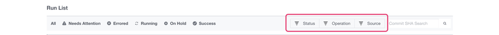

- **Status** lets you filter by the [stage of the run](https://developer.hashicorp.com/terraform/cloud-docs/api-docs/run#run-states), such as `Applied`, `Discarded`, or `Pending`.
- **Operation** lets you filter by the [run type](https://developer.hashicorp.com/terraform/cloud-docs/api-docs/run#run-operations), such as `Refresh only`, `Apply`, or `Destroy`.
- **Source** lets you filter by the [run workflow](https://developer.hashicorp.com/terraform/cloud-docs/api-docs/run#run-sources), `UI`, `VCS`, or `API`.

## Edit variables

Use variables to make your configuration flexible enough to use in different contexts. Setting variable values is one of the most common ways to customize Terraform configuration, and HCP Terraform supports multiple ways to manage variables.

Like Terraform Community Edition, you can pass per-run variables to HCP Terraform using command line flags. When using the CLI-driven workflow for HCP Terraform, any variables passed using the `-var` flag will override workspace-specific variables. However, HCP Terraform will not save the new value in your workspace unless you update the variable in the UI. This feature can be useful when you want to test or temporarily apply a change that you expect to revert on the next apply, so your stored variable values continue to reflect the desired eventual configuration.

In your terminal, start a new Terraform run for your workspace. Use a command line variable to update the instance type for your EC2 instance to `t2.small`.

```
$ terraform apply -var="instance_type=t2.small"
Running apply in HCP Terraform. Output will stream here. Pressing Ctrl-C
will cancel the remote apply if it's still pending. If the apply started it
will stop streaming the logs, but will not stop the apply running remotely.

Preparing the remote apply...

To view this run in a browser, visit:
https://app.terraform.io/app/hashicorp-training/learn-terraform/runs/run-zRZTVvu....
##...
```

Once again, Terraform will trigger a run in your `learn-terraform` workspace and stream the output to your terminal. You can also review the details for the run in the workspace itself.

[figure not shown]

The Terraform AWS provider determined that it can modify your instance type in place. Approve the run to resize your EC2 instance.

## Next Steps

Review the documentation on [variables in HCP Terraform](https://developer.hashicorp.com/terraform/cloud-docs/workspaces/variables#precedence) to learn more about variable precedence in a workspace.

In these tutorials, you created an HCP Terraform account and organization, authenticated from the command line, created an HCP Terraform workspace, and used the CLI-driven workflow to create and modify infrastructure.

In the next tutorial, you will update your workspace settings to instead use the VCS-driven workflow and trigger Terraform operations off of pull requests.

© 2026 HashiCorp  
Licensed under the MPL 2.0 License.  
https://developer.hashicorp.com/terraform/tutorials/cloud/cloud-change